# Tutorial de Machine Learning com R

### Para começar, carregamos algumas libs e nossos dados

```r
library(tidyverse) #Funções de utilidade gerais para Data Science
library(rpart) # para arvores de regressão
library(randomForest) # para Random Forests

melb_data <- read_csv("data/melb_data.csv") #Os dados

melb_data <- na.omit(melb_data) #Removendo os valores nulos
```

### Sumarizando os dados

```r
summary(melb_data)
```

```
       X1           Suburb            Address              Rooms
 Min.   :    2   Length:6196        Length:6196        Min.   :1.000
 1st Qu.: 4545   Class :character   Class :character   1st Qu.:2.000
 Median : 9346   Mode  :character   Mode  :character   Median :3.000
 Mean   : 9632                                         Mean   :2.931
 3rd Qu.:14545                                         3rd Qu.:4.000
 Max.   :19739                                         Max.   :8.000
     Type               Price            Method
 Length:6196        Min.   : 131000   Length:6196
 Class :character   1st Qu.: 620000   Class :character
 Mode  :character   Median : 880000   Mode  :character
                    Mean   :1068828
                    3rd Qu.:1325000
                    Max.   :9000000
   SellerG              Date              Distance         Postcode
 Length:6196        Length:6196        Min.   : 0.000   Min.   :3000
 Class :character   Class :character   1st Qu.: 5.900   1st Qu.:3044
 Mode  :character   Mode  :character   Median : 9.000   Median :3081
                                       Mean   : 9.751   Mean   :3102
                                       3rd Qu.:12.400   3rd Qu.:3147
                                       Max.   :47.400   Max.   :3977
    Bedroom2        Bathroom          Car            Landsize
 Min.   :0.000   Min.   :1.000   Min.   : 0.000   Min.   :    0
 1st Qu.:2.000   1st Qu.:1.000   1st Qu.: 1.000   1st Qu.:  152
 Median :3.000   Median :1.000   Median : 1.000   Median :  373
 Mean   :2.902   Mean   :1.576   Mean   : 1.574   Mean   :  471
 3rd Qu.:3.000   3rd Qu.:2.000   3rd Qu.: 2.000   3rd Qu.:  628
 Max.   :9.000   Max.   :8.000   Max.   :10.000   Max.   :37000
  BuildingArea      YearBuilt    CouncilArea          Lattitude
 Min.   :   0.0   Min.   :1196   Length:6196        Min.   :-38.16
 1st Qu.:  91.0   1st Qu.:1940   Class :character   1st Qu.:-37.86
 Median : 124.0   Median :1970   Mode  :character   Median :-37.80
 Mean   : 141.6   Mean   :1964                      Mean   :-37.81
 3rd Qu.: 170.0   3rd Qu.:2000                      3rd Qu.:-37.76
 Max.   :3112.0   Max.   :2018                      Max.   :-37.46
   Longtitude     Regionname        Propertycount
 Min.   :144.5   Length:6196        Min.   :  389
 1st Qu.:144.9   Class :character   1st Qu.: 4384
 Median :145.0   Mode  :character   Median : 6567
 Mean   :145.0                      Mean   : 7435
 3rd Qu.:145.1                      3rd Qu.:10175
 Max.   :145.5                      Max.   :21650
```

Cada ‘chunk’ da saída acima nos mostra uma colula dos dados. Para colunas não numéricas vemos apenas algumas informações básicas, como o seu tamanho. Para colunas númericas vemos algumas informações a mais, como média, mediana, os quartis, o mínimo e o máximo e a quantidade de NA’s nos dados.

### Construindo um Modelo

Para construir um modelo preditivo precisamos

1. Definir qual a variável alvo que queremos prever, chamada de Variável Dependente na estatistica. Para esse exemplo vamos usar o preço das residencias
2. Definir qual modelo usaremos para realizar a predição. Vamos começar com arvores de decisão
3. Treinar o modelo
4. Realizar predições utilizando o modelo
5. Medir a acurácia do modelo

```r
fit <- rpart(Price ~ Rooms + Bathroom + Landsize + BuildingArea +
             YearBuilt + Lattitude + Longtitude, data = melb_data)
```

Acima criamos nosso modelo, uma árvore de decisão. O primeiro parametro a formulá que a arvore de decisão utilizara, no nosso caso a formula indica que queremos prever nossa variável dependente (Preço) em função de algumas variáveis independentes (Quartos, banheiros, etc). O segundo parametro indica de onde vem os dados que o modelo utilizará no treino.

Vamos dar uma olhada em como ficou

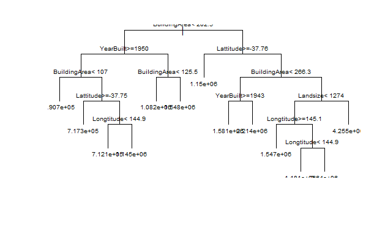

```r
plot(fit, uniform = TRUE) #Plota o gráfico da regressão
text(fit, cex=.6) # Adiciona textos e legendas e os torna 60% maior que o default
```

### Predição

Vamos utilizar nosso modelo de treino para realizar algumas predições

```r
print("6 primeiras casas:")
```

```
[1] "6 primeiras casas:"
```

```r
print(head(melb_data))
```

| X1 | Suburb | Address | Rooms | Type | Price | Method | SellerG | Date | Distance | Postcode | Bedroom2 | Bathroom | Car | Landsize | BuildingArea | YearBuilt | CouncilArea | Lattitude | Longtitude | Regionname | Propertycount |
| --- | --- | --- | --- | --- | --- | --- | --- | --- | --- | --- | --- | --- | --- | --- | --- | --- | --- | --- | --- | --- | --- |
| 2 | Abbotsford | 25 Bloomburg St | 2 | h | 1035000 | S | Biggin | 4/02/2016 | 2.5 | 3067 | 2 | 1 | 0 | 156 | 79 | 1900 | Yarra | -37.8079 | 144.9934 | Northern Metropolitan | 4019 |
| 4 | Abbotsford | 5 Charles St | 3 | h | 1465000 | SP | Biggin | 4/03/2017 | 2.5 | 3067 | 3 | 2 | 0 | 134 | 150 | 1900 | Yarra | -37.8093 | 144.9944 | Northern Metropolitan | 4019 |
| 6 | Abbotsford | 55a Park St | 4 | h | 1600000 | VB | Nelson | 4/06/2016 | 2.5 | 3067 | 3 | 1 | 2 | 120 | 142 | 2014 | Yarra | -37.8072 | 144.9941 | Northern Metropolitan | 4019 |
| 11 | Abbotsford | 124 Yarra St | 3 | h | 1876000 | S | Nelson | 7/05/2016 | 2.5 | 3067 | 4 | 2 | 0 | 245 | 210 | 1910 | Yarra | -37.8024 | 144.9993 | Northern Metropolitan | 4019 |
| 14 | Abbotsford | 98 Charles St | 2 | h | 1636000 | S | Nelson | 8/10/2016 | 2.5 | 3067 | 2 | 1 | 2 | 256 | 107 | 1890 | Yarra | -37.8060 | 144.9954 | Northern Metropolitan | 4019 |
| 18 | Abbotsford | 10 Valiant St | 2 | h | 1097000 | S | Biggin | 8/10/2016 | 2.5 | 3067 | 3 | 1 | 2 | 220 | 75 | 1900 | Yarra | -37.8010 | 144.9989 | Northern Metropolitan | 4019 |

```r
print("Predição para o preço das 6 primeiras casas ")
```

```
[1] "Predição para o preço das 6 primeiras casas "
```

```r
print(predict(fit, head(melb_data)))
```

```
      1       2       3       4       5       6
1082360 1547898 1145040 2214155 1082360 1082360
```

```r
print("O Preço real das 6 primeiras casas")
```

```
[1] "O Preço real das 6 primeiras casas"
```

```r
print(head(melb_data$Price))
```

```
[1] 1035000 1465000 1600000 1876000 1636000 1097000
```

### Como saber se o nosso modelo é um bom modelo ?

Existem muitas metricas que nos fornecem informações sobre a qualidade do nossos modelos. Começaremos com uma tecnica chamada MAE (Mean Absolute Error)

Vamos definir um erro para cada predição de preços das casas como sendo:

ERROR = (Valor Real) - (Valor Predito)

O MAE seria então média dos valores absolutos dos erros para cada observação.

Veja como podemos usar o MAE no R

```r
library(modelr) #Pacote que contem a função MAE
mae(model = fit, data = melb_data)
```

```
[1] 276287.9
```

Mas existe um problema em coletarmos a métrica da forma que coletamos aqui. No mundo real vamos querer utilizar nosso modelo para dados que ainda não conhecemos, e aqui estamos calculando o MAE apenas para os dados que os nosso modelo já conhece.

Para lidar com esse problema podemos dividir nosso conjunto de dados em treino e teste. Geralmente dividimos 70% para o conjunto de treino e 30% para o conjunto d teste.

Utilizamos os dados de treino, como o proprio nome sugere para realizar toda a parte de treino do modelo, depois, utilizamos esse modelo para predizer os valores do conjunto de testes, que ele ainda nao conhece. A partir dos resultados sobre o conjunto de testes podemos realizar analises sobre como o nosso modelo está conseguindo lidar com dados que não conhece.

No R podemos dividir o modelo em treino e teste utilizando o pacote modelr da seguinte forma

```r
#Dividindo os dados
splitData <- resample_partition(melb_data, c(test = 0.3, train = 0.7))
#Verificando quantos dados ficaram em cada um dos conjuntos
lapply(splitData, dim)
```

```
$`test`
[1] 1858   22

$train
[1] 4338   22
```

Agora vamos treinar um novo modelo apenas com os dados de treino e aplicar o MAE com base nas predições dos dados de teste.

```r
fit2 <- rpart(Price ~ Rooms + Bathroom + Landsize + BuildingArea +
             YearBuilt + Lattitude + Longtitude, data = splitData$train)
mae(model = fit2, data = splitData$test)
```

```
[1] 280862.2
```

### Overfitting e Underfitting

Podemos exagerar durante o treinamento de nossos modelos e chegar em um ponto em que o nosso modelo descreve extremamente bem os dados de treino, porém não consegue generalizar nas predições de dados desconhecidos. Quando isso acontece podemos estar enfrentando um overfitting.

No outro extremo, quando nosso modelo não cosegue ir bem nem nos dados de treino, é possivel que ele não tenha conseguido reconhecer nenhum padrão nos dados, chamamos isso de underfitting. Aqui vale tentar mudar os parametros do seu modelo ou talvez, trocar de modelo.

### Tipos diferentes de modelo

Existem vários tipos de modelos, vamos tentar um diferente dessa vez, o RandomForest.

```r
library(randomForest)
fit.randomForest <- randomForest(Price ~ Rooms + Bathroom + Landsize +
                                   BuildingArea + YearBuilt + Lattitude +
                                   Longtitude, data = splitData$train)
mae(model = fit.randomForest, data = splitData$test)
```

```
[1] 177417.9
```

Comparando a métrica MAE dos dois modelos, podemos ver que o erro do random fores diminuiu bastante. Para outros dados pode acontecer o inverso, uma boa prática é tentar identificar quais os melhores modelos para o seu contexto.